# Milo workflow on Gg_ctrl_poly_int

# 1. Defining representative neighbourhoods

We define the neighbourhood of a cell, the index, as the group of cells connected by an edge in the KNN graph to the index cell. For efficiency, we don’t test for DA in the neighbourhood of every cell, but we sample as indices a subset of representative cells, using a KNN sampling algorithm used by Gut et al. 2015.

For sampling you need to define a few parameters:

[output not shown]

```r
set.seed(my.seed)
my.milo <- makeNhoods(my.milo, prop = 0.1, k = 10, d=30, refined = TRUE)
```

```
Checking valid object
Running refined sampling with reduced_dim
```

Once we have defined neighbourhoods, it’s good to take a look at how big the neighbourhoods are (i.e. how many cells form each neighbourhood). This affects the power of DA testing. We can check this out using the plotNhoodSizeHist function. Empirically, we found it’s best to have a distribution peaking between 50 and 100. Otherwise you might consider rerunning makeNhoods increasing k and/or prop (here the distribution looks ludicrous because it’s a small dataset).

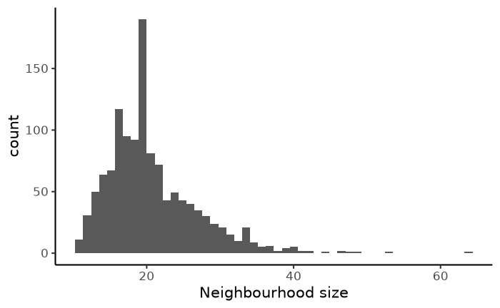

```r
plotNhoodSizeHist(my.milo)
```

## Counting cells in neighbourhoods

Now we have to count how many cells from each sample are in each neighbourhood. We need to use the cell metadata and specify which column contains the sample information.

```r
my.milo <- countCells(
              my.milo,
              meta.data = data.frame(colData(my.milo)),
              sample = "orig.ident"
              )
```

```
Checking meta.data validity
Counting cells in neighbourhoods
```

This adds to the Milo object a n m matrix, where n is the number of neighbourhoods and m

is the number of experimental samples. Values indicate the number of cells from each sample counted in a neighbourhood. This count matrix will be used for DA testing.

```r
head(nhoodCounts(my.milo))
```

```
6 x 4 sparse Matrix of class "dgCMatrix"
  Gg_ctrl_1 Gg_ctrl_2 Gg_poly_1 Gg_poly_2
1         9         3         3         8
2         6         9         6         7
3         .         9         7         6
4         2        12         2         5
5         2         9         5         5
6         3         5         2         4
```

## Differential abundance testing

Now we are all set to test for differential abundance in neighbourhoods. We implement this hypothesis testing in a generalized linear model (GLM) framework, specifically using the Negative Binomial GLM implementation in edgeR.

We first need to think about our experimental design. The design matrix should match samples to a condition of interest. In this case the Condition is the covariate we are going to test for.

```r
my.design <- data.frame(colData(my.milo))[,c("orig.ident", "cond", "batch")]
my.design <- distinct(my.design)
rownames(my.design) <- my.design[, "orig.ident"]

my.design
```

|  | orig.ident | cond | batch |
| --- | --- | --- | --- |
| Gg_ctrl_1 | Gg_ctrl_1 | Gg_c | Gg_ctrl_1 |
| Gg_ctrl_2 | Gg_ctrl_2 | Gg_c | Gg_ctrl_2 |
| Gg_poly_1 | Gg_poly_1 | Gg_p | Gg_poly_1 |
| Gg_poly_2 | Gg_poly_2 | Gg_p | Gg_poly_2 |

Milo uses an adaptation of the Spatial FDR correction introduced by cydar, which accounts for the overlap between neighbourhoods. Specifically, each hypothesis test P-value is weighted by the reciprocal of the kth nearest neighbour distance. To use this statistic we first need to store the distances between nearest neighbors in the Milo object.

```r
my.milo <- calcNhoodDistance(my.milo, d=30)
```

Now we can do the test, explicitly defining our experimental design. We want to test for differences between experimental contitions.

```r
da.results <- testNhoods(my.milo, design = ~ cond, design.df = my.design)
```

```
Using TMM normalisation
Running with model contrasts
Performing spatial FDR correction with k-distance weighting
```

This calculates a Fold-change and corrected P-value for each neighbourhood, which indicates wheather there is significant differential abundance between conditions.

```r
da.results %>%
  arrange(- SpatialFDR) %>%
  head()
```

|  | logFC | logCPM | F | PValue | FDR | Nhood | SpatialFDR |
| --- | --- | --- | --- | --- | --- | --- | --- |
| 19 | 0.0007374378 | 10.115252 | 2.981909e-08 | 0.9998635 | 0.9998635 | 19 | 0.9998635 |
| 107 | -0.0024694730 | 9.956068 | 7.764697e-06 | 0.9978012 | 0.9997371 | 107 | 0.9996083 |
| 462 | -0.0002434048 | 9.929410 | 1.823011e-06 | 0.9989329 | 0.9997371 | 462 | 0.9996083 |
| 1073 | -0.0008039239 | 10.518848 | 3.563155e-06 | 0.9985081 | 0.9997371 | 1073 | 0.9996083 |
| 1205 | 0.0088989735 | 9.637786 | 1.986192e-05 | 0.9964776 | 0.9996946 | 1205 | 0.9993999 |
| 1 | -0.2217938395 | 10.312934 | 5.496584e-02 | 0.8164460 | 0.9992163 | 1 | 0.9987796 |

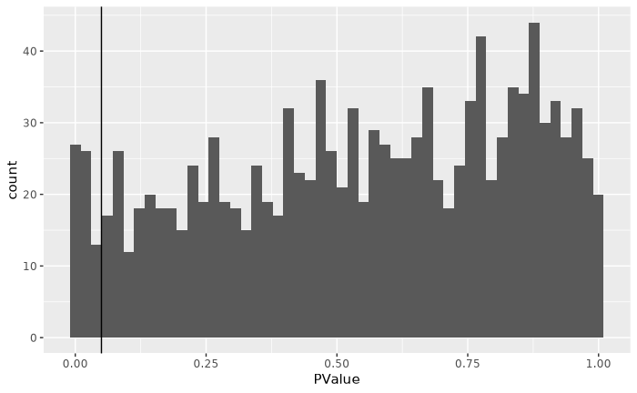

```r
res_1 <- ggplot(da.results, aes(PValue)) +
  geom_histogram(bins=50) +
  geom_vline(xintercept = 0.05)
res_1
```

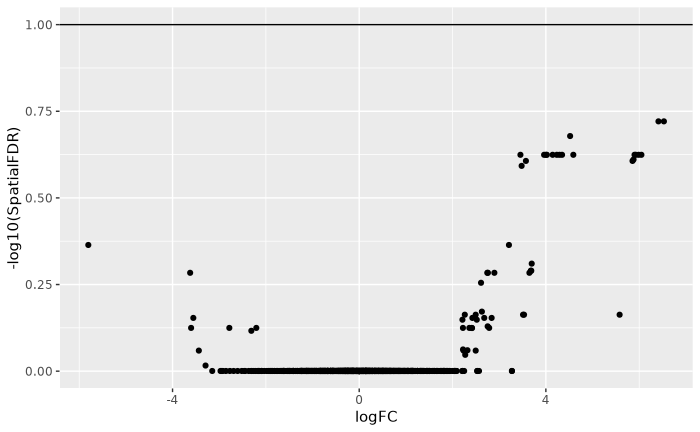

```r
res_2 <- ggplot(da.results, aes(logFC, -log10(SpatialFDR))) +
  geom_point() +
  geom_hline(yintercept = 1) ## Mark significance threshold (10% FDR)
res_2
```